# 2.3.0 Estimating Grade and Sub-Grade

We've used a multi classification model to predict the grade and sub grade process. Unlike for the previous model only different configuration of XGBoost were used. Our tuning process was similar to that used by previous model:

- Selection of optimal feature transformers (using grid search).
- Hypertuning for different traget metrics (PR-AUC, logloss and macro F1) score to select the optimal hyperparameters.

See the appendices for more details.

```
Dropping cols where: grade is missing 2034631 -> 2034601
```

```
With transform="pandas", `func` should return a DataFrame to follow the set_output API.
```

```
Total samples loaded : 2034601
```

### 2.3.1 Training and Evaluation

We've selected a configuration tuned for F1 as our "production" model. However, additional configurations were tested. It's worth noting that tuning for PR-AUC achieved comparable performance however the training time increase significantly, the configuration used `max_depth` = `12`, `learning_rate while`= `0.2` while `7`/`0.3` and setting `gamma` to `0.1` (minimum reduction in loss required to make a further partition on a leaf node of the tree) instead of `0.0` was sufficient.

```
Training: XGBoostF1Multiclass with: {'feat_trans_delinquency__option': 0, 'feat_trans_dti_inc_joint__option': 0, 'feat_trans_dummy_DROP_ALL_BUT_FICO_HIGH__option': 0, 'feat_trans_fico_score__option': 0, 'feat_trans_inst_income_ratio__option': 0, 'feat_trans_loan_grade__option': 0, 'feat_trans_new_dt…
XGBoostF1Multiclass: 3934.5 seconds
```

```
Pipeline(steps=[('preprocessing',
                 FunctionTransformer(func=<function convert_to_category at 0x7fe73d247010>)),
                ('feat_trans_loan_grade', LoanGradeTransformer()),
                ('feat_trans_dti_inc_joint', JointApplicationTransformer()),
                ('feat_trans_fico_score', FICOScoreTransformer()),
                ('feat_trans_delinquency', DelinquencyTransformer()),
                ('feat_trans_inst_income_ratio', Ins...
                               feature_types=None, gamma=0.1, grow_policy=None,
                               importance_type=None,
                               interaction_constraints=None, learning_rate=0.3,
                               max_bin=None, max_cat_threshold=None,
                               max_cat_to_onehot=None, max_delta_step=None,
                               max_depth=7, max_leaves=None,
                               min_child_weight=2.5, missing=nan,
                               monotone_constraints=None, multi_strategy=None,
                               n_estimators=150, n_jobs=None,
                               num_parallel_tree=None,
                               objective='multi:softprob', ...))])
```

#### Results:

```
'XGBoostF1Multiclass'
```

```
'CV Results:'
```

```
accuracy                 0.849
precision_macro          0.778
recall_macro             0.725
f1_macro                 0.746
log_loss                 0.401
n_samples          1627680.000
dtype: float64
```

```
'Test Split Evaluation:'
```

```
f1           0.751
accuracy     0.850
precision    0.782
recall       0.730
log_loss     2.000
dtype: float64
```

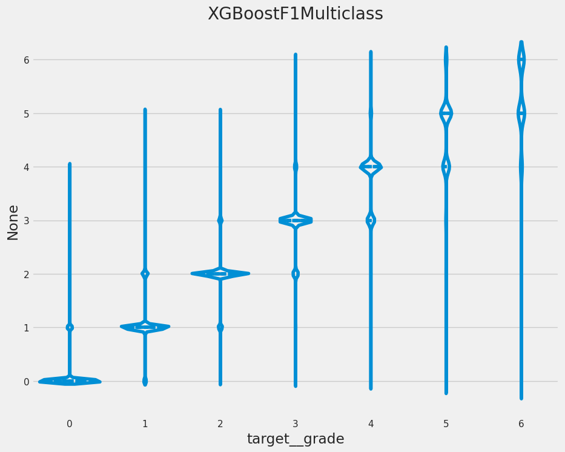

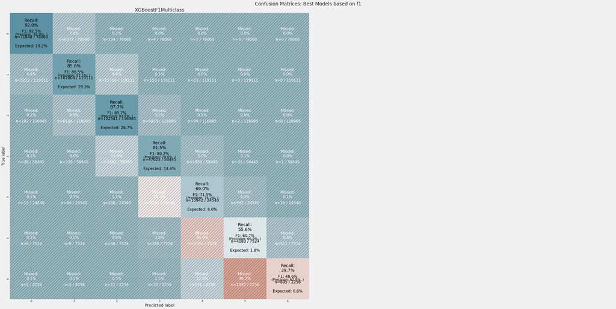

```
set_ticklabels() should only be used with a fixed number of ticks, i.e. after set_ticks() or using a FixedLocator.
```

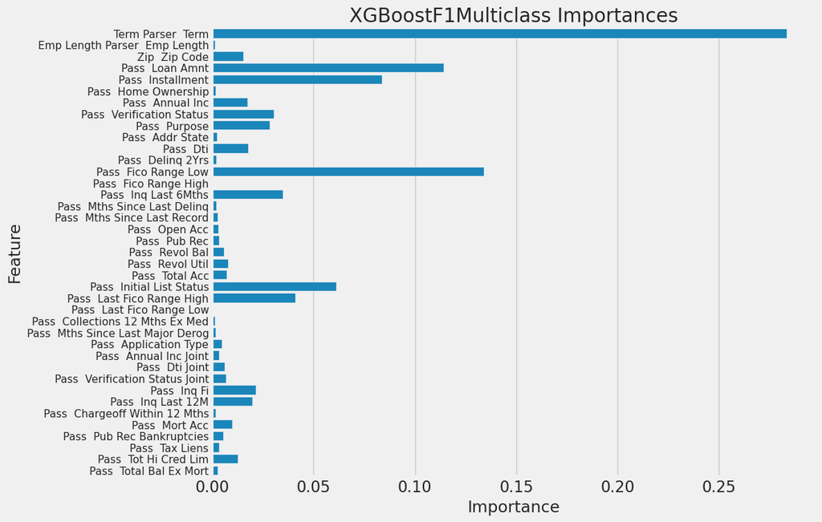

|  | Feature | Importance |
| --- | --- | --- |
| 0 | term_parser__term | 0.283267 |
| 1 | emp_length_parser__emp_length | 0.001460 |
| 2 | zip__zip_code | 0.015377 |
| 3 | pass__loan_amnt | 0.114238 |
| 4 | pass__installment | 0.083785 |
| 5 | pass__home_ownership | 0.001546 |
| 6 | pass__annual_inc | 0.017439 |
| 7 | pass__verification_status | 0.030414 |
| 8 | pass__purpose | 0.028362 |
| 9 | pass__addr_state | 0.002459 |
| 10 | pass__dti | 0.017551 |
| 11 | pass__delinq_2yrs | 0.001861 |
| 12 | pass__fico_range_low | 0.133956 |
| 13 | pass__fico_range_high | 0.000000 |
| 14 | pass__inq_last_6mths | 0.034767 |
| 15 | pass__mths_since_last_delinq | 0.001965 |
| 16 | pass__mths_since_last_record | 0.002540 |
| 17 | pass__open_acc | 0.002886 |
| 18 | pass__pub_rec | 0.003241 |
| 19 | pass__revol_bal | 0.005628 |
| 20 | pass__revol_util | 0.007873 |
| 21 | pass__total_acc | 0.007038 |
| 22 | pass__initial_list_status | 0.061059 |
| 23 | pass__last_fico_range_high | 0.040828 |
| 24 | pass__last_fico_range_low | 0.000000 |
| 25 | pass__collections_12_mths_ex_med | 0.001278 |
| 26 | pass__mths_since_last_major_derog | 0.001657 |
| 27 | pass__application_type | 0.004819 |
| 28 | pass__annual_inc_joint | 0.003288 |
| 29 | pass__dti_joint | 0.005941 |
| 30 | pass__verification_status_joint | 0.006741 |
| 31 | pass__inq_fi | 0.021314 |
| 32 | pass__inq_last_12m | 0.019824 |
| 33 | pass__chargeoff_within_12_mths | 0.001644 |
| 34 | pass__mort_acc | 0.009777 |
| 35 | pass__pub_rec_bankruptcies | 0.005268 |
| 36 | pass__tax_liens | 0.003532 |
| 37 | pass__tot_hi_cred_lim | 0.012653 |
| 38 | pass__total_bal_ex_mort | 0.002723 |

As we have learnt when building our default risk model there difference in returns and other features does not vary as much for lower quality grades which might make it hard to distinguish them. Therefore we'll use the same approach and merge E-F-G grades into a single group.

#### Merging E-F-G loan grades into a single group

```
Training: XGBoostF1Multiclass with: {'feat_trans_delinquency__option': 0, 'feat_trans_dti_inc_joint__option': 0, 'feat_trans_dummy_DROP_ALL_BUT_FICO_HIGH__option': 0, 'feat_trans_fico_score__option': 0, 'feat_trans_inst_income_ratio__option': 0, 'feat_trans_loan_grade__option': 0, 'feat_trans_new_dt…
XGBoostF1Multiclass: 224.5 seconds
```

```
'XGBoostF1Multiclass'
```

```
'CV Results:'
```

[output not shown]

```
'Test Split Evaluation:'
```

```
f1           0.801
accuracy     0.805
precision    0.813
recall       0.791
log_loss     2.000
dtype: float64
```

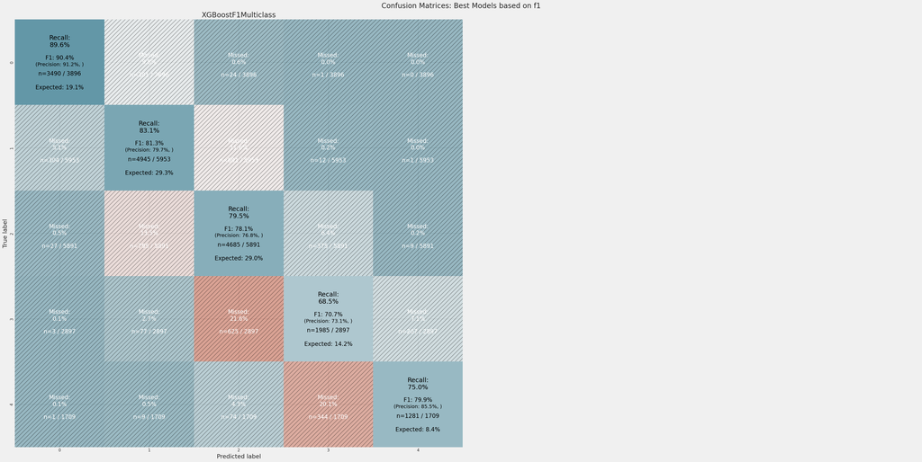

```
set_ticklabels() should only be used with a fixed number of ticks, i.e. after set_ticks() or using a FixedLocator.
```

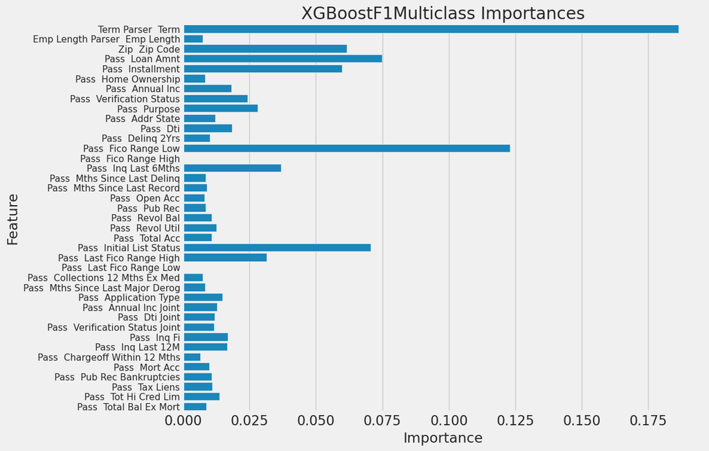

|  | Feature | Importance |
| --- | --- | --- |
| 0 | term_parser__term | 0.186359 |
| 1 | emp_length_parser__emp_length | 0.007387 |
| 2 | zip__zip_code | 0.061612 |
| 3 | pass__loan_amnt | 0.074794 |
| 4 | pass__installment | 0.059826 |
| 5 | pass__home_ownership | 0.008242 |
| 6 | pass__annual_inc | 0.018254 |
| 7 | pass__verification_status | 0.024264 |
| 8 | pass__purpose | 0.028074 |
| 9 | pass__addr_state | 0.012059 |
| 10 | pass__dti | 0.018394 |
| 11 | pass__delinq_2yrs | 0.009971 |
| 12 | pass__fico_range_low | 0.122972 |
| 13 | pass__fico_range_high | 0.000000 |
| 14 | pass__inq_last_6mths | 0.036808 |
| 15 | pass__mths_since_last_delinq | 0.008587 |
| 16 | pass__mths_since_last_record | 0.008891 |
| 17 | pass__open_acc | 0.008136 |
| 18 | pass__pub_rec | 0.008436 |
| 19 | pass__revol_bal | 0.010784 |
| 20 | pass__revol_util | 0.012640 |
| 21 | pass__total_acc | 0.010719 |
| 22 | pass__initial_list_status | 0.070690 |
| 23 | pass__last_fico_range_high | 0.031447 |
| 24 | pass__last_fico_range_low | 0.000000 |
| 25 | pass__collections_12_mths_ex_med | 0.007279 |
| 26 | pass__mths_since_last_major_derog | 0.008355 |
| 27 | pass__application_type | 0.014726 |
| 28 | pass__annual_inc_joint | 0.012731 |
| 29 | pass__dti_joint | 0.011981 |
| 30 | pass__verification_status_joint | 0.011583 |
| 31 | pass__inq_fi | 0.016773 |
| 32 | pass__inq_last_12m | 0.016616 |
| 33 | pass__chargeoff_within_12_mths | 0.006558 |
| 34 | pass__mort_acc | 0.009786 |
| 35 | pass__pub_rec_bankruptcies | 0.010853 |
| 36 | pass__tax_liens | 0.011060 |
| 37 | pass__tot_hi_cred_lim | 0.013631 |
| 38 | pass__total_bal_ex_mort | 0.008723 |

[output not shown]

#### Classifying Subgrades

```
Sampled n: 101732
Dropping cols where: sub_grade is missing 101732 -> 101730
```

```
With transform="pandas", `func` should return a DataFrame to follow the set_output API.
```

```
Total samples loaded : 101730
```

```
The y_pred values do not sum to one. Starting from 1.5 thiswill result in an error.
```

```
Training: XGBoostF1Multiclass with: {'feat_trans_delinquency__option': 0, 'feat_trans_dti_inc_joint__option': 0, 'feat_trans_dummy_DROP_ALL_BUT_FICO_HIGH__option': 0, 'feat_trans_fico_score__option': 0, 'feat_trans_inst_income_ratio__option': 0, 'feat_trans_loan_grade__option': 0, 'feat_trans_new_dt…
```

#### Predicting Sub-grades

```
'XGBoostF1Multiclass'
```

```
{'f1': 0.0877,
 'accuracy': 0.1383,
 'precision': 0.1017,
 'recall': 0.0884,
 'log_loss': 2}
```

## Conclusion

- As could have been expected the multi classification model performs significantly worse than a binary classifier.
- Performance when predicting the lower grades, especially `E-F-G` is poor. This might indicate that:
  - The algorithm used for setting the grades is not entirely fixed and the provided features can't be consistently. Classes E, F, and G might have features that are not as distinct from each other as those separating A, B, and C. This overlap can confuse the model, especially if the ordinal relationship leads to gradual changes in feature values across classes.
  - The features used might not effectively capture the variance within E, F, G, or the ordinal relationship between classes. Features that are good at differentiating A, B, C might not scale well into distinguishing E, F, G.
- The model complexity might not be sufficient to capture the nuances that would differentiate between E, F, and G. This could be due to too few trees, shallow trees, or not enough iterations. e.g.: If XGBoost is tuned with a low depth parameter, it might capture the broad differences between A, B, C well but fail to model the subtleties needed for E, F, G. However we have trained a configuration with a more complex model and the performance was not signficantly different. This might allow use to reject this hypothesis but additional testing and analysis might be necessary.